# Learning Data Science Using LCS 2020 Data

Alexander Neumyer and Michael Tang

5/17/2020

## Data Preparation

```r
library(tidyverse)

spring2020 <- read_csv("lcsdata.csv")

tidy_spring2020 <- spring2020 %>%
  filter(league=="LCS", position!="team") %>%
  select(gameid, league, side, position, player, team, champion, ban1, ban2, ban3, ban4, ban5, gamelength,
         result, kills, deaths, assists, teamkills, teamdeaths, damagetochampions, dpm, damageshare,
         wardsplaced, wpm, controlwardsbought, visionscore, totalgold, "total cs", cspm)  %>%
  rename(totalcs = "total cs")

tidy_spring2020 <- tidy_spring2020 %>%
  mutate(visionscore = as.numeric(visionscore)) %>%
  mutate(totalcs = as.numeric(totalcs))

head(tidy_spring2020)
```

```
## # A tibble: 6 x 29
##   gameid league side  position player team  champion ban1  ban2  ban3  ban4
##   <chr>  <chr>  <chr> <chr>    <chr>  <chr> <chr>    <chr> <chr> <chr> <chr>
## 1 ESPOR~ LCS    Blue  top      Licor~ Clou~ Aatrox   Irel~ Ornn  Luci~ Ekko
## 2 ESPOR~ LCS    Blue  jng      Blaber Clou~ Lee Sin  Irel~ Ornn  Luci~ Ekko
## 3 ESPOR~ LCS    Blue  mid      Nisqy  Clou~ Veigar   Irel~ Ornn  Luci~ Ekko
## 4 ESPOR~ LCS    Blue  bot      Zven   Clou~ Aphelios Irel~ Ornn  Luci~ Ekko
## 5 ESPOR~ LCS    Blue  sup      Vulcan Clou~ Tahm Ke~ Irel~ Ornn  Luci~ Ekko
## 6 ESPOR~ LCS    Red   top      Impact Team~ Mordeka~ Akali Qiya~ Rumb~ Zoe
## # ... with 18 more variables: ban5 <chr>, gamelength <dbl>, result <dbl>,
## #   kills <dbl>, deaths <dbl>, assists <dbl>, teamkills <dbl>,
## #   teamdeaths <dbl>, damagetochampions <dbl>, dpm <dbl>, damageshare <chr>,
## #   wardsplaced <dbl>, wpm <dbl>, controlwardsbought <dbl>, visionscore <dbl>,
## #   totalgold <dbl>, totalcs <dbl>, cspm <dbl>
```

## Machine Learning - Linear Regression

For the next section, we will focus on using data science tools to approximate models for correlation in data. Basically, we are going to use parts of R and the broom library to try and model certain stat combinations. Here is an example: I believe that there is a relationship between an ADC’s damage to champions and total gold. One would expect that with more gold, ADC’s would do more damage to champions as they would be able to buy more items. So, I will mutate the dataframe to only look at ADC’s, their damage per minute, and their total gold. I am using damage per minute (dpm) over total damage to champions to avoid miscalculating the correlation due to variable game times.

There is also code for graphing the relationship between total gold and dpm, just to compare to the results from the model.

```r
library(broom)
ml1df <- tidy_spring2020 %>%
  filter(position=="bot") %>%
  select(dpm, totalgold)
head(ml1df)
```

```
## # A tibble: 6 x 2
##     dpm totalgold
##   <dbl>     <dbl>
## 1  459.     10312
## 2  232.      8151
## 3  591.     13469
## 4  518.     17386
## 5  546.     14895
## 6  599.     14079
```

```r
dvgmodel <- lm(dpm~ totalgold, data=ml1df)
tidy(dvgmodel)
```

```
## # A tibble: 2 x 5
##   term        estimate std.error statistic  p.value
##   <chr>          <dbl>     <dbl>     <dbl>    <dbl>
## 1 (Intercept)   9.02    39.0         0.232 8.17e- 1
## 2 totalgold     0.0335   0.00268    12.5   4.21e-28
```

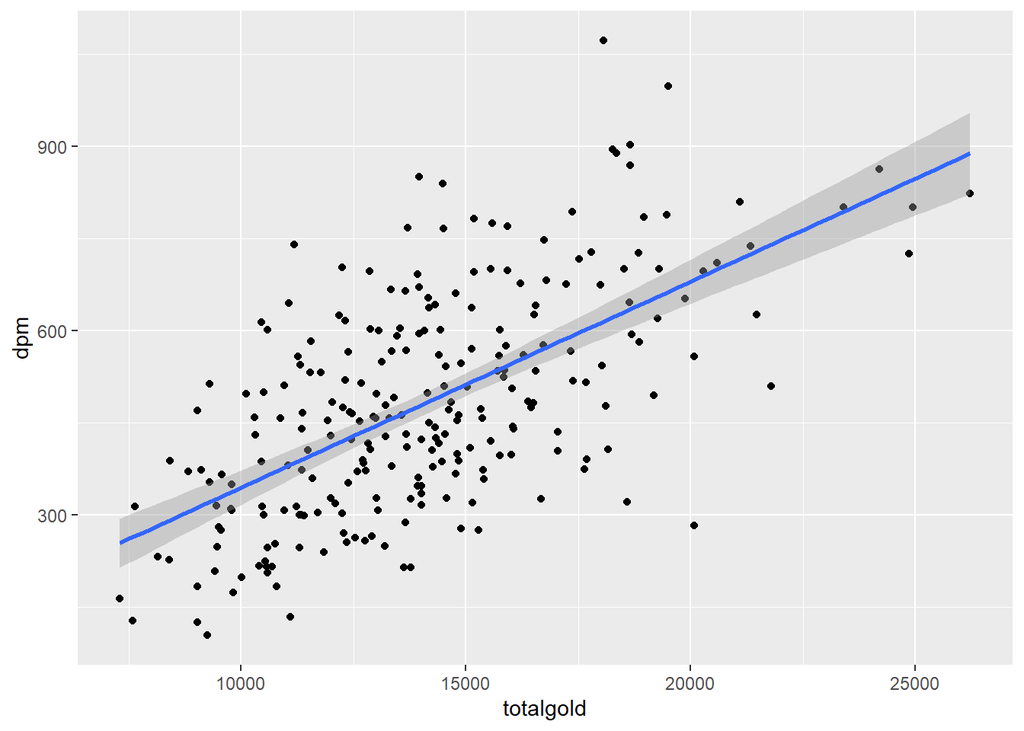

```r
ml1df %>%
  ggplot(aes(x=totalgold, y=dpm)) +
  geom_point() +
  geom_smooth(method=lm)
```

This method is suggesting this model: dpm = 9.022 + 0.034 * totalgold. This suggests that for every 1000 gold gained by an ADC, their DPM should increase by 34. Comparing to the graph, this looks close enough, from 15000 to 20000 looks to around a 150-200 dpm increase.

However, this isn’t enough for us, we need to check how accurate our model is. To do that, we will use “glance” from the broom package to check the r-squared value for this model.

```r
dvgmodel %>%
  glance() %>%
  select(r.squared)
```

```
## # A tibble: 1 x 1
##   r.squared
##       <dbl>
## 1     0.386
```

One way we can amend this is by including another variable. Thinking aboutLCS and the professional scene as a whole, a big reason as to why some teams win a lot and some teams lose a lot is due to individual player skill. So, we should include an interaction between the player and total gold.

```r
playdvgdf <- tidy_spring2020 %>%
  filter(position=="bot", player=="Zven" | player=="Bang" | player=="Doublelift") %>%
  select(dpm, totalgold, player)
head(playdvgdf)
```

```
## # A tibble: 6 x 3
##     dpm totalgold player
##   <dbl>     <dbl> <chr>
## 1  459.     10312 Zven
## 2  232.      8151 Doublelift
## 3  457.     10886 Bang
## 4  534.     16558 Zven
## 5  700.     18526 Bang
## 6  321.     18585 Doublelift
```

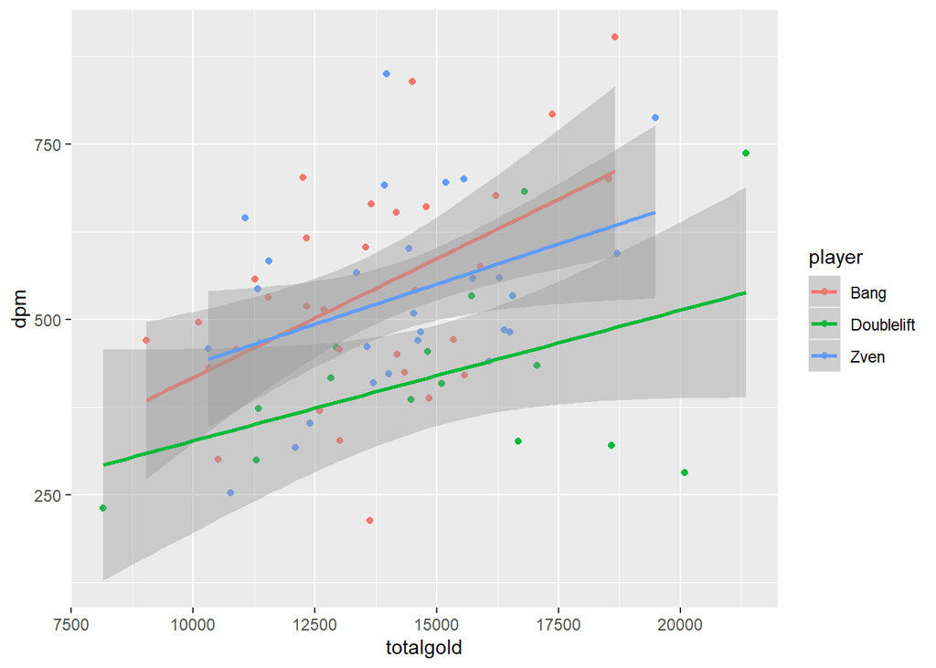

```r
playdvgdf %>%
  ggplot(aes(x=totalgold, y=dpm, color=player)) +
  geom_point() +
  geom_smooth(method=lm)
```

The above graph compares dpm to total gold for Bang, Doublelift, and Zven (ADC’s for EG, TL, and C9, respectively). This suggests that our previous model was indeed incorrect to exclude individual player skill, as their individual models look very different. While Doublelift and Zven have similar slopes to their regression lines, their intercepts are widely different. Bang’s regression line has a similar intercept to Zven’s regression line, but has a greater slope, suggesting his DPM increases more per gold gained. So lets make a model that includes player as an interaction.

Our interaction would look like this: DPM ~= TotalGold * Player. Since player is a string of characters and not a number, we have to use a different way of representing it in our model. The easiest way is to make a list of every ADC player and give each one a 0 or 1 depending on if they are playing.

Model: DPM ~= Player1 * TotalGold + Player2 * TotalGold + … + PlayerN * TotalGold

When we try to predict for Player3, we would put a 0 for every other player, and a 1 for Player3. This would cause the model to simplify to just DPM ~= Player3*TotalGold, where Player3 is 1. This allows us to have a different coefficient for each player, and possibly achieve a better model for comparing total gold and dpm. However, this will mean that our data will look a little messy, as we will see a lot more output. But lets just try it!

```r
#This code looks at the old model, but only with 3 players' data.
newdvgmodel <- lm(dpm~ totalgold, data=playdvgdf)
tidy(newdvgmodel)
```

```
## # A tibble: 2 x 5
##   term        estimate std.error statistic p.value
##   <chr>          <dbl>     <dbl>     <dbl>   <dbl>
## 1 (Intercept) 223.      90.5          2.47 0.0159
## 2 totalgold     0.0205   0.00629      3.26 0.00169
```

```r
newdvgmodel %>%
  glance() %>%
  select(r.squared)
```

```
## # A tibble: 1 x 1
##   r.squared
##       <dbl>
## 1     0.129
```

```r
#This code looks at the new model, but only with 3 players' data.
playdvgmodel <- lm(dpm~ player*totalgold, data=playdvgdf)
tidy(playdvgmodel)
```

```
## # A tibble: 6 x 5
##   term                       estimate std.error statistic p.value
##   <chr>                         <dbl>     <dbl>     <dbl>   <dbl>
## 1 (Intercept)                 78.8     141.         0.559 0.578
## 2 playerDoublelift            62.4     210.         0.297 0.767
## 3 playerZven                 129.      211.         0.612 0.543
## 4 totalgold                    0.0339    0.0102     3.32  0.00146
## 5 playerDoublelift:totalgold  -0.0153    0.0143    -1.07  0.290
## 6 playerZven:totalgold        -0.0110    0.0149    -0.737 0.463
```

```r
playdvgmodel %>%
  glance() %>%
  select(r.squared)
```

```
## # A tibble: 1 x 1
##   r.squared
##       <dbl>
## 1     0.289
```

You might see a little more code here than you were expecting, so let me explain. When I first ran the code testing the new model, I realized there were a lot of players to look at, so to keep it simple, I filtered the dataset to only be Doublelift, Zven, and Bang. Then, looking at the result from glance, I saw that the r-squared value was EVEN WORSE than before (hard to believe, I know). I realized that this was due to the fact that I was only focusing on three players this time. So, by re-running the old model but only on those three players, I was able to see an r-squared value that better represented our changes.

The first table shows the statistics for the old model on the filtered data set. The second table shows the r-squared value for the model in the first table. The third table shows the new model on the filtered data set. The fourth table shows the r-squared value for the model in the third table. That’s a lot of tables.

Let me explain the third table. The broom package lm method selects a specific variable (player) to call the “baseline”. In this example, Bang was selected as the baseline (alphabetical order). So to read Doublelift’s coefficients from this table, you take Bang’s intercept (term = (Intercept)), and then add the “playerDoublelift” estimate to it to get the intercept coefficient used for Doublelift’s model. For Doublelift’s total gold coefficient you do the same: totalgold is Bang’s total gold coefficient, so just add playerDoublelift:totalgold to it to get Doublelift’s total gold coefficient. Notice that the p-value of every row is > 0.05 except for the totalgold row. That suggests that there is a correlation between totalgold and DPM, but it doesn’t really depend on player, as there wasn’t a statistically significant difference between each player’s total gold coefficients.

The main thing I want to convey is that changing our model actually improved the r-squared value, as the old model (for those three players) has an r-squared value of 0.129, while the new model has an r-squared value of 0.289. As to why these are both below the r-squared value of the old model conditioned on all of the ADC’s, well, I don’t really have an answer. It could be because some of those players had much less game time, so there was less data to work off and they were swinging the model. It could also be that Zven, Doublelift, and Bang are all great players that don’t need gold to improve their DPM, while the other ADC players really require gold, so the other players were meeting the model, while these three don’t have a good model that fits them.

Our r-squared value is still very low, and to counter that, I would suggest trying all manner of combinations at home! You can add on variables with “+”, or add more interactions by multiplying them with "*".

## Tree Models

Linear regression models aren’t the only type of predictor out there. In fact, there are so many you would probably have to take multiple college courses to learn them all. I am not going to explain them all, but lets look at one more, cooler to look at, model.

Model: Result = WPM + CSPM

```r
library(tree)

jgdf <- tidy_spring2020 %>%
  filter(position=="jng") %>%
  select(result, wpm, cspm, player)
head(jgdf)
```

```
## # A tibble: 6 x 4
##   result   wpm  cspm player
##    <dbl> <dbl> <dbl> <chr>
## 1      1 0.407  4.60 Blaber
## 2      0 0.244  5.62 Shernfire
## 3      0 0.845  5.64 Wiggily
## 4      1 0.92   4.82 Grig
## 5      1 0.815  4.15 Meteos
## 6      0 0.289  4.47 Closer
```

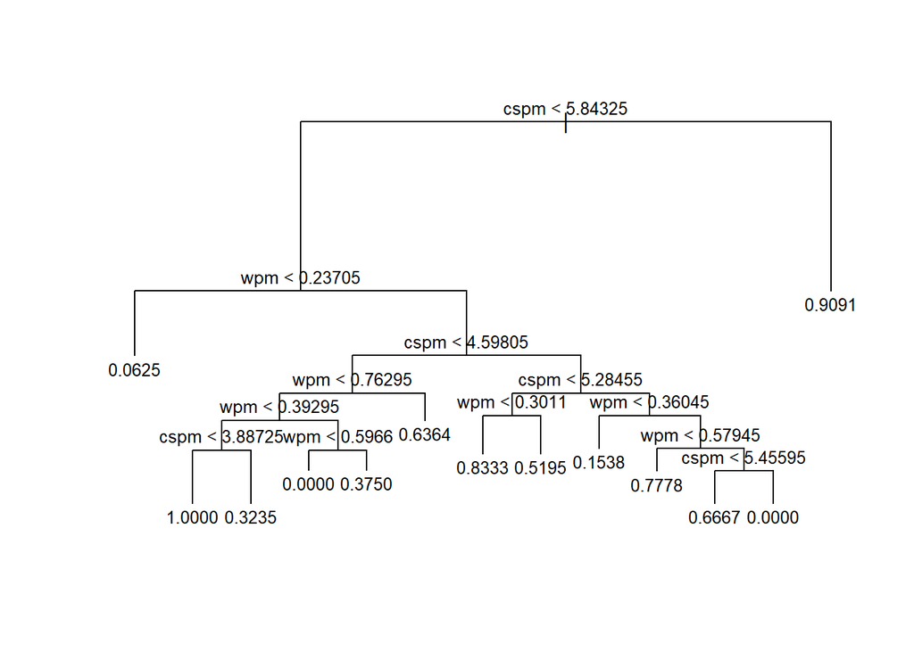

```r
tree <- tree(result~ wpm + cspm, data=jgdf)
plot(tree)
text(tree, pretty=0, cex=0.8)
```

Figuring out if this model is good is harder, as there aren’t any easy to use functions like “glance”. So I’ll do a little loose testing. I’ll starting by using the tree package “predict” method, which allows me to give it a dataset to run through the model. Then I will check how many of those are correct according to the actual data and show the results.

```r
newjgdf <- jgdf %>%
  filter(player=="Closer") %>%
  mutate(betterres= ifelse(result == 1, "Yes", "No"))

tree_pred_prob <- predict(tree, newjgdf)
tree_pred <- ifelse(tree_pred_prob > 0.5, "Yes", "No")
print(table(predicted=tree_pred, observed=newjgdf$betterres))
```

```
##          observed
## predicted No Yes
##       No   8   1
##       Yes  5   8
```

I decided to start by only focusing on Closer (GG’s jungler), and seeing if the tree could predict his winrate. Looking at this data, there were only 22 games for it to pull from, so you should immediately realize that the sample size is a bit small. It would definitely help if we could include past years, but then you need to take into account roster swaps.

This table shows that our tree model got 8 losses correct and 8 wins correct, however it said there was 1 win that Closer should have lost, and 5 losses that it believes Closer should have won. Seems this tree is a Golden Guardians fan! This is a small data set, but these differences seem large enough for us to say that our model probably isn’t amazing when it comes to predict wins and losses off of just jungler cspm and wpm.

There are many ways to improve this model, and you can do more testing by selecting other players, or selecting a random set of data to test with. The best way to test your model is to select a set of data to test with, remove it from the model-making data, make the model, and then test using that random data. This ensures that random data was not used to make the model, which means the model won’t have been influenced by that set of data. I chose data that was a part of the model-making data in this example just to show how it would work, and because I knew the sample size was small.

## Hypothesis Testing

Hypothesis testing is a very important statistical tool that allows us to suggest correlations and check if they are correct. Watching the games from this past split, I noticed Ornn was pick or ban, where he would be seen every game as either a played champion or banned away. I wondered to myself if banning him was actually a good option, or if those teams were hurting their future. So, lets suggest that banning Ornn decreases a team’s chance of winning.

For hypothesis testing, you set up a null hypothesis, which is the opposite of what you believe, and an alternate hypothesis, which is what you believe. For our example: Null Hypothesis: Win percentage of games where Ornn is banned = 50% Alternate Hypothesis: Win percentage of games where Ornn is banned < 50%

So, lets jump into the code!

First, I need to cut out the parts I don’t need. I want to make sure every side of every game is represented only once, and that I only see the bans and the result.

```r
htdf <- tidy_spring2020 %>%
  select(gameid, side, ban1, ban2, ban3, result) %>%
  distinct()
head(htdf)
```

```
## # A tibble: 6 x 6
##   gameid                side  ban1   ban2   ban3      result
##   <chr>                 <chr> <chr>  <chr>  <chr>      <dbl>
## 1 ESPORTSTMNT02/1270555 Blue  Irelia Ornn   Lucian         1
## 2 ESPORTSTMNT02/1270555 Red   Akali  Qiyana Rumble         0
## 3 ESPORTSTMNT02/1270576 Blue  Irelia Qiyana Gangplank      0
## 4 ESPORTSTMNT02/1270576 Red   Akali  Lucian Rumble         1
## 5 ESPORTSTMNT02/1270592 Blue  Qiyana Rumble Senna          1
## 6 ESPORTSTMNT02/1270592 Red   Akali  Lucian Aphelios       0
```

```r
upddf <- htdf %>%
  mutate(ornnban = ifelse(htdf$ban1 == "Ornn" | htdf$ban2 == "Ornn" | htdf$ban2 == "Ornn", 1, 0)) %>%
  select(-ban1, -ban2, -ban3, -side, -gameid) %>%
  group_by(result) %>%
  summarize(ornnbanned=sum(ornnban), notbanned=sum(ornnban*0 + 1) - sum(ornnban))
head(upddf)
```

```
## # A tibble: 2 x 3
##   result ornnbanned notbanned
##    <dbl>      <dbl>     <dbl>
## 1      0         21       104
## 2      1         19       106
```

```r
phat = 19/(21+19)
p0 = .5
n = 40
z = (phat - p0)/sqrt(p0*(1-p0)/n)
pnorm(z)
```

```
## [1] 0.3759148
```

This number (0.376) is quite high for a p-value, and since it is greater than 0.05 (default alpha level for statistics), we cannot reject the null, and cannot determine if banning Ornn hurts a team’s win percentage.

To continue with making fun graphs in R with ggplot, lets look at how often teams were picking Aatrox. I filtered so Aatrox would be the only champion shown, and then counted the number of occurences while grouping by team.

```r
graphdf <- tidy_spring2020 %>%
  group_by(team) %>%
  filter(champion=="Aatrox") %>%
  summarize(num_aatrox=n())
graphdf
```

```
## # A tibble: 10 x 2
##    team                 num_aatrox
##    <chr>                     <int>
##  1 100 Thieves                  12
##  2 Cloud9                        8
##  3 Counter Logic Gaming          5
##  4 Dignitas                      2
##  5 Evil Geniuses                 9
##  6 FlyQuest                     16
##  7 Golden Guardians              9
##  8 Immortals                     4
##  9 Team Liquid                   2
## 10 Team SoloMid                  8
```

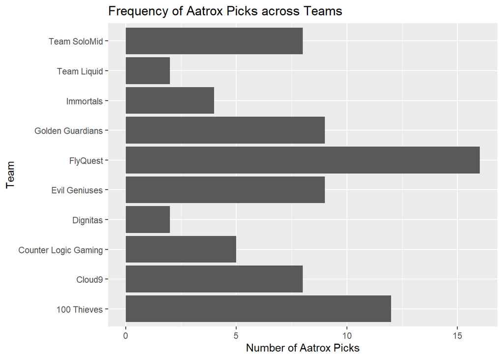

```r
graphdf %>%
  ggplot(mapping=aes(y=num_aatrox, x=team)) + geom_bar(stat="identity") + coord_flip() + ylab("Number of Aatrox Picks") + xlab("Team") + ggtitle("Frequency of Aatrox Picks across Teams")
```

Based off of this graph, we can see that Viper (FQ’s top) loves Aatrox. Many people believe that Aatrox is overpowered, but this shows that Cloud9 didn’t abuse him for their success. Pick any variables and plug them into ggplot to get cool visuals.